# Анализ музыкальных предпочтений пользователей сервиса Яндекс Музыка в Москве и Санкт-Петербурге

Москва и Санкт-Петербург — два крупнейших города, две столицы, два сердца страны. Каждый из этих городов имеет свои уникальные особенности и культурные традиции.

Оба города являются мегаполисами с высоким уровнем развития и интенсивной жизнью. Более активный и быстрый ритм жизни — в Москве: высокий уровень коммерциализации и развитая инфраструктура способствуют установлению динамичного темпа жизни, с большим количеством событий и широкими возможностями. В Санкт-Петербурге, напротив, — более спокойный и размеренный ритм жизни. Наличие в городе множества парковых зон и регулярное проведение культурных мероприятий создают более расслабленную и творческую атмосферу.

Санкт-Петербург является культурной столицей России и имеет богатое наследие в области искусства, литературы и музыки. Москва также имеет богатое культурное наследие и является центром искусства, науки и образования. Москва и Санкт-Петербург — оба являются культурными столицами России, но отличаются своими архитектурными стилями, историческим наследием и уникальным характером. Каждый город имеет свою уникальную атмосферу.

Схожие черты и наличие различий — всё это делает Москву и Санкт-Петербург интересными для исследований и сравнений.

Москва предлагает более широкий спектр музыкальных возможностей. Здесь можно найти концерты и выступления практически любых музыкальных жанров — от классической музыки и джаза до рока, поп-музыки и электронной музыки. Москва часто становится местом проведения крупных фестивалей и концертов мировых звёзд. Санкт-Петербург также имеет богатую музыкальную сцену. Город известен своими классическими музыкальными концертами и оперными выступлениями. Санкт-Петербург также является центром русского рока.

Музыкальные предпочтения жителей разных городов являются субъективными и могут сильно отличаться у каждого индивида. Они могут зависеть от множества факторов, таких как возраст, пол, культурные особенности человека и другие особенности его личности. Но оказывает ли влияние на музыкальные предпочтения город, в котором живёт человек?

Чтобы ответить на этот вопрос нужны данные, которые помогут выявить предпочтения жителей Москвы и Санкт-Петербурга в выборе музыки, которую они слушают. Выявленное преобладание музыкального жанра в выборе слушателей будет означать, что он имеет большую популярность и привлекательность для аудитории по сравнению с другими жанрами. Такое преобладание одного или нескольких музыкальных жанров, возможно, будет обусловлено ещё и такими факторами, как модные тенденции и социокультурные влияния в городе.

Яндекс Музыка — это сервис потокового музыкального контента. Он позволяет пользователям из разных городов слушать музыку онлайн и оффлайн, создавать плейлисты, получать рекомендации, следить за новинками музыкальной индустрии. Пользователям доступен каталог с десятками миллионов музыкальных треков разных жанров и исполнителей.

Анализ данных о том, какие жанры музыки предпочитают слушать в сервисе Яндекс Музыка жители Москвы и Санкт-Петербурга, поможет понять, что больше всего нравится именно этому сегменту пользователей и что ещё можно им предложить. Кроме того, это позволит выявить популярные жанры и тренды в музыке, что, в свою очередь, может быть полезным для авторов и исполнителей музыкальных композиций.

В нашем распоряжении находятся данные сервиса Яндекс Музыка: сведения о пользователях и прослушанных ими треках. Для каждого пользователя доступна информация о городе проживания, для каждого трека — информация о названии, исполнителе и жанре музыкальной композиции, также имеются сведения о дне недели и времени прослушивания треков пользователями.

**Цель проекта:** проверить гипотезы:

1. Количество прослушанных пользователями сервиса треков зависит от дня недели, причём оно изменяется по-разному у пользователей из разных городов — Москвы и Санкт-Петербурга.
2. Жанры, в которых пользователи предпочитают слушать музыку в понедельник утром или в пятницу вечером, — разные в разных городах — Москве и Санкт-Петербурге.
3. Пользователи из разных городов предпочитают слушать музыку разных жанров: в Москве чаще слушают поп-музыку, в Санкт-Петербурге — русский рэп.

**Задачи исследования:**

- выполнить предобработку данных;
- изучить обработанные данные;
- найти особенности и выявить зависимости между признаками.

# Содержание

## Обзор данных

### Импорт библиотек и предварительные настройки

```python
import pandas as pd
import matplotlib.pyplot as plt
import numpy as np
import seaborn as sns
import sys
import os

pd.set_option('display.max_columns', None)
np.set_printoptions(threshold=sys.maxsize)
```

### Чтение файлов и загрузка данных

Все данные хранятся в одном файле.  
Файл данных `yandex_music_project.csv` имеет формат `CSV`.

```python
pth1 = r'C:\Users\Георгий\Documents\DS_projects\yandex_music_project.csv'
pth2 = '/datasets/yandex_music_project.csv'
pth3 = '/content/yandex_music_project.csv'

if os.path.exists(pth1):
    data = pd.read_csv(pth1)
elif os.path.exists(pth2):
    data = pd.read_csv(pth2)
elif os.path.exists(pth3):
    data = pd.read_csv(pth3)
else:
    print('Something is wrong')
```

Убедимся, что данные подгрузились верно, без ошибок.

Для этого выведем первые 10 строк и последние 10 строк набора данных.

```python
data.head(10)
```

|  | userID | Track | artist | genre | City | time | Day |
| --- | --- | --- | --- | --- | --- | --- | --- |
| 0 | FFB692EC | Kamigata To Boots | The Mass Missile | rock | Saint-Petersburg | 20:28:33 | Wednesday |
| 1 | 55204538 | Delayed Because of Accident | Andreas Rönnberg | rock | Moscow | 14:07:09 | Friday |
| 2 | 20EC38 | Funiculì funiculà | Mario Lanza | pop | Saint-Petersburg | 20:58:07 | Wednesday |
| 3 | A3DD03C9 | Dragons in the Sunset | Fire + Ice | folk | Saint-Petersburg | 08:37:09 | Monday |
| 4 | E2DC1FAE | Soul People | Space Echo | dance | Moscow | 08:34:34 | Monday |
| 5 | 842029A1 | Преданная | IMPERVTOR | rusrap | Saint-Petersburg | 13:09:41 | Friday |
| 6 | 4CB90AA5 | True | Roman Messer | dance | Moscow | 13:00:07 | Wednesday |
| 7 | F03E1C1F | Feeling This Way | Polina Griffith | dance | Moscow | 20:47:49 | Wednesday |
| 8 | 8FA1D3BE | И вновь продолжается бой | NaN | ruspop | Moscow | 09:17:40 | Friday |
| 9 | E772D5C0 | Pessimist | NaN | dance | Saint-Petersburg | 21:20:49 | Wednesday |

```python
data.tail(10)
```

|  | userID | Track | artist | genre | City | time | Day |
| --- | --- | --- | --- | --- | --- | --- | --- |
| 65069 | BE1AAD74 | Waterwalk | Eduardo Gonzales | electronic | Moscow | 20:38:59 | Monday |
| 65070 | 49F35D53 | Ass Up | Rameez | dance | Moscow | 14:08:58 | Friday |
| 65071 | 92378E24 | Swing it Like You Mean it | OJOJOJ | techno | Moscow | 21:12:56 | Friday |
| 65072 | C532021D | We Can Not Be Silenced | Pänzer | extrememetal | Moscow | 08:38:24 | Friday |
| 65073 | 83A474E7 | I Worship Only What You Bleed | The Black Dahlia Murder | extrememetal | Moscow | 21:07:12 | Monday |
| 65074 | 729CBB09 | My Name | McLean | rnb | Moscow | 13:32:28 | Wednesday |
| 65075 | D08D4A55 | Maybe One Day (feat. Black Spade) | Blu & Exile | hip | Saint-Petersburg | 10:00:00 | Monday |
| 65076 | C5E3A0D5 | Jalopiina | NaN | industrial | Moscow | 20:09:26 | Friday |
| 65077 | 321D0506 | Freight Train | Chas McDevitt | rock | Moscow | 21:43:59 | Friday |
| 65078 | 3A64EF84 | Tell Me Sweet Little Lies | Monica Lopez | country | Moscow | 21:59:46 | Friday |

### Общая характеристика набора данных

Размер набора данных:

```python
data.shape
```

```
(65079, 7)
```

Уникальные наименования признаков:

```python
data.columns.sort_values().tolist()
```

```
['  City  ', '  userID', 'Day', 'Track', 'artist', 'genre', 'time']
```

Количество элементов данных:

```python
data.size
```

```
455553
```

Типы данных набора данных:

```python
data.dtypes.value_counts()
```

```
object    7
Name: count, dtype: int64
```

Пропущенные значения в данных:

```python
data.isna().sum()
```

```
  userID       0
Track       1231
artist      7203
genre       1198
  City         0
time           0
Day            0
dtype: int64
```

Всего пропущенных элементов данных:

```python
data.isna().sum().sum()
```

```
9632
```

Распределение пропущенных значений в наборе данных:

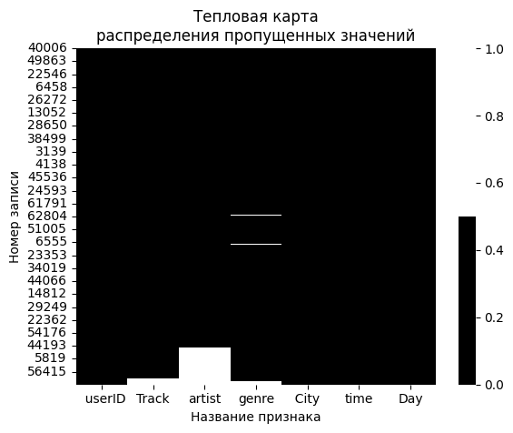

```python
sns.heatmap(data.sort_values(by=['artist', 'Track', 'genre']).isna(),
            cmap=sns.color_palette(['#000000', '#ffffff']))
plt.title('Тепловая карта\nраспределения пропущенных значений')
plt.xlabel('Название признака')
plt.ylabel('Номер записи')
plt.show()
```

### Преобразование наименований признаков

Приведение названий столбцов к "змеиному_регистру".

```python
data = data.rename(
    columns=lambda column:
    ' '.join(column.split()).lower())
data.rename(columns={'userid': 'user_id'}, inplace=True)
data.columns.tolist()
```

```
['user_id', 'track', 'artist', 'genre', 'city', 'time', 'day']
```

## Понимание данных

Все данные можно разделить на две категории:

- данные, описывающие трек: название, имя исполнителя и жанр;
- данные о пользователе: из какого он города, когда он слушал музыку.

***Сведения о музыкальных композициях***

> **Название трека** — это название песни или композиции, под которым она представлена в каталоге сервиса Яндекс Музыка.

Название трека обычно указывается артистом или лейблом, выпустившим песню, и помогает идентифицировать композицию и отличать её от других композиций.

`track` — название трека  
Признак является категориальным, номинальным.  
Шкала измерения признака: номинальная шкала.

> **Имя исполнителя** трека — это информация о музыканте или группе, которые представлены в сервисе и исполняют музыкальные композиции.

Информация об имени исполнителя в сервисе Яндекс Музыка обычно отображается вместе с названием трека и является ещё одной частью уникальной идентификации музыкальной композиции. Имя исполнителя также используют для поиска и прослушивания треков, а также для создания индивидуальных плейлистов и создания персонализированных рекомендаций, основанных на предпочтениях пользователя.

`artist` — имя исполнителя  
Признак является категориальным, номинальным.  
Шкала измерения признака: номинальная шкала.

> **Название жанра** трека — это информация о стиле или направлении, к которому относится данный трек.

В сервисе Яндекс Музыка представлены треки широкого спектра жанров: от популярных направлений (поп, рок, хип-хоп, электронная музыка) до более специфических. Название жанра обычно отображается вместе с названием трека и именем исполнителя и помогает пользователям находить музыку, соответствующую их вкусам и предпочтениям.

`genre` — название жанра  
Признак является категориальным, номинальным.  
Шкала измерения признака: номинальная шкала.

***Сведения о пользователях***

> **Уникальный идентификатор пользователя** — это уникальный код или номер, который присваивается каждому пользователю при регистрации на сервисе Яндекс Музыка.

Идентификатор позволяет системе отличать одного пользователя от другого и предоставлять ему персонализированный контент и функциональные возможности. Как правило, уникальный идентификатор представлен в виде цифр или буквенно-цифровой комбинации.

`user_id` — идентификатор пользователя  
Признак является категориальным, номинальным.  
Шкала измерения признака: номинальная шкала.

> **Город местонахождения пользователя** — это географическое местоположение устройства, с которого пользователь использует сервис в текущий момент времени.

Сервис может использовать эту информацию для предоставления персонализированных музыкальных рекомендаций с учётом предпочтений других пользователей, находящихся в том же городе.

`city` — город местонахождения пользователя  
Признак является категориальным, бинарным.  
Шкала измерения признака: дихотомическая шкала.

*Хронометрические данные*

> **День недели** и **время начала прослушивания** трека — это момент времени (в течение определённого дня недели), в который пользователь запускает воспроизведение данного трека.

Информацию можно использовать в анализе популярности и предпочтений слушателей в зависимости от дня недели и времени в течение одного дня, и можно использовать для составления плейлистов или рекомендаций.

`day` — день недели прослушивания трека  
Признак является категориальным, ординальным.  
Шкала измерения признака: порядковая шкала.

`time` — время начала прослушивания трека  
Признак является количественным, непрерывным.  
Шкала измерения признака: интервальная шкала.

## Предобработка данных

### Обработка пропусков

```python
total = data.isna().sum().sort_values(ascending=False)
percent = (data.isna().sum() /
           data.isna().count() * 100).round(1).sort_values(ascending=False)
pd.concat([total, percent], axis=1, keys=['Всего пропусков', '%'])
```

|  | Всего пропусков | % |
| --- | --- | --- |
| artist | 7203 | 11.1 |
| track | 1231 | 1.9 |
| genre | 1198 | 1.8 |
| user_id | 0 | 0.0 |
| city | 0 | 0.0 |
| time | 0 | 0.0 |
| day | 0 | 0.0 |

Поскольку название трека и имя исполнителя являются идентификационными данными музыкальной композиции, по другим признакам не представляется возможным заполнить эти значения. Жанр композиции не всегда удаётся указать, отталкиваясь от того, в каких жанрах у исполнителя написаны другие песни, поскольку один исполнитель может исполнять песни, написанные в разных жанрах. Тем более, это сложно сделать, если в наборе данных отсутствуют сведения о других песнях этого же исполнителя.

Поскольку других возможностей восстановить пропущенные значения нет, заполним их значением 'unknown'.

```python
data[['track', 'artist', 'genre']] = \
data[['track', 'artist', 'genre']].fillna('unknown')

data.isna().sum().sum()
```

```
0
```

### Обработка текстовых значений

```python
data['genre'].sort_values().unique()
```

```
array(['acid', 'acoustic', 'action', 'adult', 'africa', 'afrikaans',
       'alternative', 'alternativepunk', 'ambient', 'americana',
       'animated', 'anime', 'arabesk', 'arabic', 'arena',
       'argentinetango', 'art', 'audiobook', 'author', 'avantgarde',
       'axé', 'baile', 'balkan', 'beats', 'bigroom', 'black', 'bluegrass',
       'blues', 'bollywood', 'bossa', 'brazilian', 'breakbeat', 'breaks',
       'broadway', 'cantautori', 'cantopop', 'canzone', 'caribbean',
       'caucasian', 'celtic', 'chamber', 'chanson', 'children', 'chill',
       'chinese', 'choral', 'christian', 'christmas', 'classical',
       'classicmetal', 'club', 'colombian', 'comedy', 'conjazz',
       'contemporary', 'country', 'cuban', 'dance', 'dancehall',
       'dancepop', 'dark', 'death', 'deep', 'deutschrock', 'deutschspr',
       'dirty', 'disco', 'dnb', 'documentary', 'downbeat', 'downtempo',
       'drum', 'dub', 'dubstep', 'eastern', 'easy', 'electronic',
       'electropop', 'emo', 'entehno', 'epicmetal', 'estrada', 'ethnic',
       'eurofolk', 'european', 'experimental', 'extrememetal', 'fado',
       'fairytail', 'film', 'fitness', 'flamenco', 'folk', 'folklore',
       'folkmetal', 'folkrock', 'folktronica', 'forró', 'frankreich',
       'französisch', 'french', 'funk', 'future', 'gangsta', 'garage',
       'german', 'ghazal', 'gitarre', 'glitch', 'gospel', 'gothic',
       'grime', 'grunge', 'gypsy', 'handsup', "hard'n'heavy", 'hardcore',
       'hardstyle', 'hardtechno', 'hip', 'hip-hop', 'hiphop',
       'historisch', 'holiday', 'hop', 'horror', 'house', 'hymn', 'idm',
       'independent', 'indian', 'indie', 'indipop', 'industrial',
       'inspirational', 'instrumental', 'international', 'irish', 'jam',
       'japanese', 'jazz', 'jewish', 'jpop', 'jungle', 'k-pop',
       'karadeniz', 'karaoke', 'kayokyoku', 'korean', 'laiko', 'latin',
       'latino', 'leftfield', 'local', 'lounge', 'loungeelectronic',
       'lovers', 'malaysian', 'mandopop', 'marschmusik', 'meditative',
       'mediterranean', 'melodic', 'metal', 'metalcore', 'mexican',
       'middle', 'minimal', 'miscellaneous', 'modern', 'mood', 'mpb',
       'muslim', 'native', 'neoklassik', 'neue', 'new', 'newage',
       'newwave', 'nu', 'nujazz', 'numetal', 'oceania', 'old', 'opera',
       'orchestral', 'other', 'piano', 'podcasts', 'pop', 'popdance',
       'popelectronic', 'popeurodance', 'poprussian', 'post',
       'posthardcore', 'postrock', 'power', 'progmetal', 'progressive',
       'psychedelic', 'punjabi', 'punk', 'quebecois', 'ragga', 'ram',
       'rancheras', 'rap', 'rave', 'reggae', 'reggaeton', 'regional',
       'relax', 'religious', 'retro', 'rhythm', 'rnb', 'rnr', 'rock',
       'rockabilly', 'rockalternative', 'rockindie', 'rockother',
       'romance', 'roots', 'ruspop', 'rusrap', 'rusrock', 'russian',
       'salsa', 'samba', 'scenic', 'schlager', 'self', 'sertanejo',
       'shanson', 'shoegazing', 'showtunes', 'singer', 'ska', 'skarock',
       'slow', 'smooth', 'soft', 'soul', 'soulful', 'sound', 'soundtrack',
       'southern', 'specialty', 'speech', 'spiritual', 'sport',
       'stonerrock', 'surf', 'swing', 'synthpop', 'synthrock',
       'sängerportrait', 'tango', 'tanzorchester', 'taraftar', 'tatar',
       'tech', 'techno', 'teen', 'thrash', 'top', 'traditional',
       'tradjazz', 'trance', 'tribal', 'trip', 'triphop', 'tropical',
       'türk', 'türkçe', 'ukrrock', 'unknown', 'urban', 'uzbek',
       'variété', 'vi', 'videogame', 'vocal', 'western', 'world',
       'worldbeat', 'ïîï', 'электроника'], dtype=object)
```

```python
len(data['genre'].unique())
```

```
290
```

Среди значений жанра встречаются неявные дубликаты: названия одного жанра на разных языках или части названия одного жанра. Устраним неявные дубликаты, приведём наименования дублирующихся жанров к одному наименованию.

```python
data['genre'] = data['genre'].replace(['hip', 'hop', 'hip-hop'], 'hiphop')
data['genre'] = data['genre'].replace('neue', 'new')
data['genre'] = data['genre'].replace('shanson', 'chanson')
data['genre'] = data['genre'].replace('türkçe', 'türk')
data['genre'] = data['genre'].replace('электроника', 'electronic')

len(data['genre'].unique())
```

```
283
```

### Обработка дубликатов

```python
data[data.duplicated(keep=False)].sort_values(by=['user_id', 'track']).head(10)
```

|  | user_id | track | artist | genre | city | time | day |
| --- | --- | --- | --- | --- | --- | --- | --- |
| 15410 | 1001CE90 | Invasion | Nick Arundel | videogame | Moscow | 09:35:01 | Monday |
| 39981 | 1001CE90 | Invasion | Nick Arundel | videogame | Moscow | 09:35:01 | Monday |
| 4542 | 100261F9 | Jump | Kris Kross | hiphop | Moscow | 14:42:21 | Friday |
| 64923 | 100261F9 | Jump | Kris Kross | hiphop | Moscow | 14:42:21 | Friday |
| 3845 | 10189D10 | Alia Aventuro | La Perdita Generacio | pop | Saint-Petersburg | 09:07:49 | Wednesday |
| 18944 | 10189D10 | Alia Aventuro | La Perdita Generacio | pop | Saint-Petersburg | 09:07:49 | Wednesday |
| 7051 | 10189D10 | Jolene | Hey Ocean! | alternative | Saint-Petersburg | 09:42:17 | Wednesday |
| 56707 | 10189D10 | Jolene | Hey Ocean! | alternative | Saint-Petersburg | 09:42:17 | Wednesday |
| 517 | 10189D10 | Kontra krusadanto | Dochamar | pop | Saint-Petersburg | 14:34:24 | Monday |
| 39972 | 10189D10 | Kontra krusadanto | Dochamar | pop | Saint-Petersburg | 14:34:24 | Monday |

```python
data.duplicated().sum()
```

```
3826
```

В наборе данных 3826 полных дубликатов. Удалим их.

```python
data.drop_duplicates(inplace=True)
data.duplicated().sum()
```

```
0
```

```python
data.shape
```

```
(61253, 7)
```

**Промежуточный вывод**

- Выполнена предварительная обработка данных.
- В результате предварительной обработки данных:
  - устранены ошибки в значениях признаков: синонимы в значениях признаков приведены к одному значению,
  - заполнены пропуски значением-заглушкой,
  - обнаружены и удалены полные дубликаты,
  - сохранено 94 % записей исходного набора данных.

## Исследовательский анализ

### Описательный анализ

#### Идентификатор пользователя

```python
len(data['user_id'].unique())
```

```
41748
```

```python
pd.DataFrame(data['user_id'].value_counts().head(10)) \
    .reset_index().rename(
    columns={'user_id': 'ID пользователя',
             'count': 'Количество треков'})
```

|  | ID пользователя | Количество треков |
| --- | --- | --- |
| 0 | A8AE9169 | 71 |
| 1 | 7D166C63 | 51 |
| 2 | 414F229D | 50 |
| 3 | E8339398 | 43 |
| 4 | EED05948 | 36 |
| 5 | D6A03F1E | 36 |
| 6 | B5496034 | 34 |
| 7 | B851E1A5 | 33 |
| 8 | 3E4BFAA7 | 31 |
| 9 | 39EDC574 | 30 |

- В 61 253 записях содержится информация о 41 748 уникальных пользователях.
- 10 человек прослушали треки 30 и более раз.
- Максимальное количество треков — 71 — прослушал один пользователь.

#### Город местонахождения пользователя

```python
data['city'].unique()
```

```
array(['Saint-Petersburg', 'Moscow'], dtype=object)
```

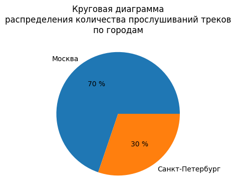

```python
data['city'].value_counts().rename(
    index={'Moscow': 'Москва',
           'Saint-Petersburg': 'Санкт-Петербург'}
).plot(
    kind='pie',
    figsize=(4, 4),
    title='Круговая диаграмма' +
          '\nраспределения количества прослушиваний треков' +
          '\nпо городам',
    label='',
    autopct='%.0f %%')
plt.show()
```

```python
pd.DataFrame(data['city'].value_counts().rename(
    index={'Moscow': 'Москва',
           'Saint-Petersburg': 'Санкт-Петербург'})) \
    .reset_index() \
    .rename(columns={'city': 'Город',
                     'count': 'Количество прослушиваний'}) \
    .set_index('Город').T
```

| Город | Москва | Санкт-Петербург |
| --- | --- | --- |
| Количество прослушиваний | 42741 | 18512 |

- В наборе данных имеются сведения о прослушанных треках только в городах Санкт-Петербурге и Москве.
- Соотношение количества записей о прослушанных треках в Москве к количеству записей о прослушанных треках в Санкт-Петербурге равно 7 : 3.

#### Название трека

```python
len(data['track'].unique())
```

```
47246
```

```python
pd.DataFrame(data['track'].value_counts().head(10)) \
    .reset_index().rename(
    columns={'track': 'Название трека',
             'count': 'Количество прослушиваний'})
```

|  | Название трека | Количество прослушиваний |
| --- | --- | --- |
| 0 | unknown | 1155 |
| 1 | Intro | 34 |
| 2 | Home | 27 |
| 3 | Stay | 22 |
| 4 | Closer | 21 |
| 5 | Time | 21 |
| 6 | All of Me | 21 |
| 7 | Fire | 20 |
| 8 | Heartbeat | 20 |
| 9 | Alone | 19 |

- В 61 253 записях содержится информация о 47 246 уникальных названиях треков.
- Некоторые треки — 1155 — не имеют названия. Это почти 2 % всех записей.
- Наиболее часто встречаются названия "Intro" — 34 раза, "Home" — 27 раз, "Stay" — 22 раза.

#### Имя исполнителя

```python
len(data['artist'].unique())
```

```
43606
```

```python
pd.DataFrame(data['artist'].value_counts().head(10)) \
    .reset_index().rename(
    columns={'artist': 'Имя исполнителя',
             'count': 'Количество треков'})
```

|  | Имя исполнителя | Количество треков |
| --- | --- | --- |
| 0 | unknown | 6772 |
| 1 | Sasha | 6 |
| 2 | Grey | 5 |
| 3 | Amir | 5 |
| 4 | Samra | 5 |
| 5 | Aura | 5 |
| 6 | Lila | 5 |
| 7 | Enigma | 5 |
| 8 | Sabrina | 5 |
| 9 | Rocket | 5 |

- В 61 253 записях содержится информация о 43 606 уникальных исполнителях.
- Для большого числа треков — 6772 — не известно имя исполнителя. Это 11 % всех записей.
- Наиболее часто встречается исполнитель "Sasha" — 6 раз.

#### Название жанра

```python
len(data['genre'].unique())
```

```
283
```

```python
pd.DataFrame(data['genre'].value_counts().head(15)) \
    .reset_index().rename(
    columns={'genre': 'Название жанра',
             'count': 'Количество треков'})
```

|  | Название жанра | Количество треков |
| --- | --- | --- |
| 0 | pop | 8323 |
| 1 | dance | 6367 |
| 2 | rock | 5844 |
| 3 | electronic | 5523 |
| 4 | hiphop | 3056 |
| 5 | classical | 2262 |
| 6 | alternative | 2028 |
| 7 | world | 1947 |
| 8 | ruspop | 1910 |
| 9 | rusrap | 1725 |
| 10 | jazz | 1466 |
| 11 | metal | 1210 |
| 12 | unknown | 1127 |
| 13 | soundtrack | 1116 |
| 14 | folk | 972 |

- Все треки относятся к 282 уникальным жанрам.
- Для некоторых треков не определён жанр — их 1127. Это почти 2 % всех записей.
- В топ-5 жанров входят поп, танцевальная музыка, рок, электронная музыка и хип-хоп.

#### День недели прослушивания трека

```python
data['day'].unique()
```

```
array(['Wednesday', 'Friday', 'Monday'], dtype=object)
```

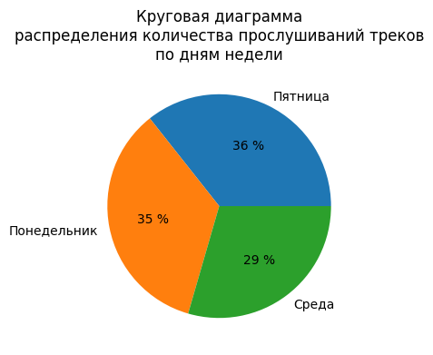

```python
data['day'].value_counts().rename(
    index={'Monday': 'Понедельник',
           'Wednesday': 'Среда',
           'Friday': 'Пятница'}
).plot(
    kind='pie',
    figsize=(4, 4),
    title='Круговая диаграмма' +
          '\nраспределения количества прослушиваний треков' +
          '\nпо дням недели',
    label='',
    autopct='%.0f %%')
plt.show()
```

- В наборе данных представлены сведения только о трёх днях недели, в которые пользователи слушали треки: понедельник, среда и пятница.
- Распределение записей между днями недели почти одинаковое: 35 % треков прослушаны в понедельник, 29 % — в среду, 36 % — в пятницу.

#### Время начала прослушивания трека

```python
data['time'].min()
```

```
'08:00:00'
```

```python
data['time'].max()
```

```
'22:00:59'
```

Приведём значения признака `time` к формату даты и времени.

```python
data['time'] = pd.to_datetime(data['time'], format='%H:%M:%S')
data['time'].dtypes
```

```
dtype('<M8[ns]')
```

Создадим признак `hour` со значением времени, округлённого до часа в меньшую сторону.

```python
data['hour'] = data['time'].dt.hour
data[['time', 'hour']].head()
```

|  | time | hour |
| --- | --- | --- |
| 0 | 1900-01-01 20:28:33 | 20 |
| 1 | 1900-01-01 14:07:09 | 14 |
| 2 | 1900-01-01 20:58:07 | 20 |
| 3 | 1900-01-01 08:37:09 | 8 |
| 4 | 1900-01-01 08:34:34 | 8 |

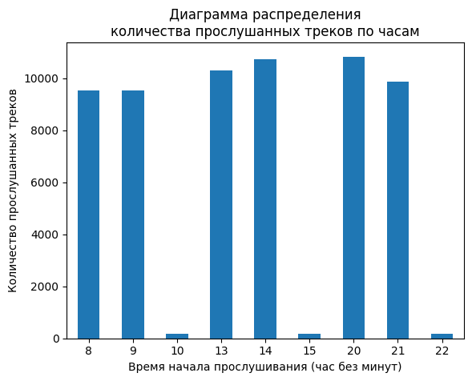

```python
plt.title('Диаграмма распределения' +
          '\nколичества прослушанных треков по часам')
data['hour'].value_counts().sort_index().plot.bar(rot=0)
plt.xlabel('Время начала прослушивания (час без минут)')
plt.ylabel('Количество прослушанных треков')
plt.show()
```

- Самое раннее время прослушивания треков — 08:00, самое позднее — 22:00:59.
- В наборе данных выделены три группы записей в зависимости от того, когда пользователи начинали воспроизводить треки: с 08:00 до 10:00, с 13:00 до 15:00 и с 20:00 до 22:00.
- Маленький люфт времени после 10:00, 15:00 и 22:00 длиной в одну минуту вызван техническими особенностями при формировании набора данных. Однако данные и за эту минуту тоже будут включены в анализ. Таким образом, длительность временного промежутка получается одинаковой для каждой группы записей и составляет 121 минуту.
- Количество записей между группами распределено практически одинаково. В каждый час прослушивают около 10 тыс. треков.

### Проверка гипотез

#### Сравнение поведения пользователей двух столиц

```python
pivot = data.pivot_table(
    index='city',
    columns='day',
    values='user_id',
    aggfunc='count'
).reset_index()
pivot = pivot[['city', 'Monday', 'Wednesday', 'Friday']]
pivot
```

| day | city | Monday | Wednesday | Friday |
| --- | --- | --- | --- | --- |
| 0 | Moscow | 15740 | 11056 | 15945 |
| 1 | Saint-Petersburg | 5614 | 7003 | 5895 |

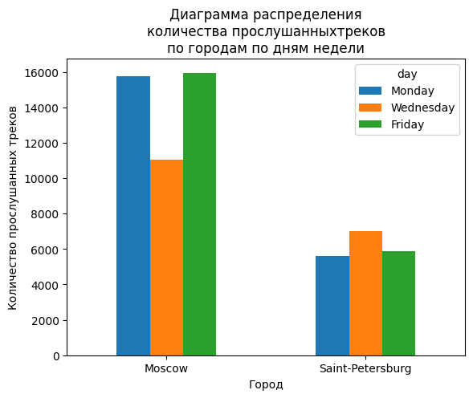

```python
data.pivot_table(
    index='city',
    columns='day',
    values='user_id',
    aggfunc='count'
)[['Monday', 'Wednesday', 'Friday']].plot.bar(
    rot=0,
    title='Диаграмма распределения' +
          '\nколичества прослушанныхтреков' +
          '\nпо городам по дням недели',
    xlabel='Город',
    ylabel='Количество прослушанных треков')
plt.show()
```

#### Музыка в начале и в конце недели

***Жанровые предпочтения утром понедельника***

```python
data.loc[(data['city'] == 'Moscow') &
         (data['day'] == 'Monday') &
         (data['hour'] < 11),
         'genre'].value_counts().head(10)
```

```
genre
pop            781
dance          549
electronic     480
rock           474
hiphop         286
ruspop         186
world          181
rusrap         175
alternative    164
unknown        161
Name: count, dtype: int64
```

```python
data.loc[(data['city'] == 'Saint-Petersburg') &
         (data['day'] == 'Monday') &
         (data['hour'] < 11),
         'genre'].value_counts().head(10)
```

```
genre
pop            218
dance          182
rock           162
electronic     147
hiphop          80
ruspop          64
alternative     58
rusrap          55
jazz            44
classical       40
Name: count, dtype: int64
```

- В понедельник утром в Москве и Санкт-Петербурге слушают похожую музыку: списки топ-10 жанров практически одинаковые. Отличие состоит только в том, что в Москве в топ-10 входит жанр “world”, а в Санкт-Петербурге — жанры джаз и классика.
- В Москве в топ-10 наблюдается значение "unknown", которое находится на десятом месте. Таким образом, пропущенные значения в признаке `genre` занимают существенную долю в данных и могут искажать распределение треков по жанрам и снижать достоверность исследования.

***Жанровые предпочтения вечером пятницы***

```python
data.loc[(data['city'] == 'Moscow') &
         (data['day'] == 'Friday') &
         (data['hour'] > 17),
         'genre'].value_counts().head(10)
```

```
genre
pop            713
rock           517
dance          495
electronic     482
hiphop         273
world          208
ruspop         170
classical      163
alternative    163
rusrap         142
Name: count, dtype: int64
```

```python
data.loc[(data['city'] == 'Saint-Petersburg') &
         (data['day'] == 'Friday') &
         (data['hour'] > 17),
         'genre'].value_counts().head(10)
```

```
genre
pop            256
electronic     216
rock           216
dance          210
hiphop          97
alternative     63
jazz            61
classical       60
rusrap          59
world           54
Name: count, dtype: int64
```

#### Жанровые предпочтения в Москве и Петербурге

```python
data.loc[data['city'] == 'Moscow', 'genre'].value_counts().head(10)
```

```
genre
pop            5892
dance          4435
rock           3965
electronic     3786
hiphop         2096
classical      1616
world          1432
alternative    1379
ruspop         1372
rusrap         1161
Name: count, dtype: int64
```

```python
data.loc[data['city'] == 'Saint-Petersburg', 'genre'].value_counts().head(10)
```

```
genre
pop            2431
dance          1932
rock           1879
electronic     1737
hiphop          960
alternative     649
classical       646
rusrap          564
ruspop          538
world           515
Name: count, dtype: int64
```

- В Москве самый популярный жанр — поп-музыка. Кроме того, в списке топ-10 жанров встречается близкий жанр — русская популярная музыка.
- В Санкт-Петербурге также предпочитают больше слушать популярную музыку. Именно этот жанр занимает верхнюю строчку списка топ-10 жанров. В списке топ-10 тоже встречается и русская поп-музыка.
- Рэп даже не входит в топ-5 жанров. В списке топ-10 жанров, которые предпочитают жители Санкт-Петербурга, рэп находится на 8 месте, а в топ-10 жанров, которые предпочитают жители Москвы, — на 10 месте.

## Общий вывод

В наборе данных представлены сведения о прослушанных треках жителями Москвы и Санкт-Петербурга. Всего 61 253 записей. Причём количество тректов, прослушанных в Москве и Санкт-Петербурге, относится как 7 : 3.

Большая часть записей относится к уникальным пользователям сервиса — 41 748 человек. Некоторые из пользователей слушали более 30 треков. Максимально прослушанное число треков — 71.

Все представленные треки относятся к 282 различным жанрам. Около 2 % треков не имеют явно указанного жанра. Самыми популярными жанрами являются поп, танцевальная музыка, рок, электронная музыка и хип-хоп.

Авторами треков являются 43 606 уникальных исполнителя. Для примерно 11 % треков исполнитель не известен. Самым популярным исполнителем оказался "Sasha". Его треки слушали 6 раз.

Всего в наборе данных встречается 47 246 уникальных названий треков. У приблизительно 2 % треков название не известно. Наиболее часто встречаются названия "Intro" — 34 раза, "Home" — 27 раз, "Stay" — 22 раза. Это не обязательно должны быть одни и те же музыкальные композиции, поскольку у разных авторов могут быть схожие названия их произведений.

В наборе данных представлены сведения о прослушивании треков пользователями сервиса в понедельник, среду и пятницу во временные интервалы: с 08:00 до 10:00, с 13:00 до 15:00 и с 20:00 до 22:00. Количество треков распределено практически поровну между днями недели. Поровну распределены треки и в трёх временных интервалах.

В результате исследования удалось проверить гипотезы и установить, что:

1. Действительно, количество прослушанных пользователями сервиса треков зависит от дня недели, причём это количество изменяется по-разному у пользователей из разных городов — Москвы и Санкт-Петербурга.

2. Жанры, в которых пользователи предпочитают слушать музыку в понедельник утром или в пятницу вечером, — практически одинаковые в Москве и Санкт-Петербурге.

3. Пользователи из Москвы и Санкт-Петербурга предпочитают слушать музыку схожих жанров: наиболее популярным жанром является поп-музыка. Рэп слушают гораздо реже и в Москве, и в Санкт-Петербурге.

Гипотеза о том, что пользователи из разных городов предпочитают слушать музыку разных жанров: в Москве чаще слушают поп-музыку, в Санкт-Петербурге — русский рэп, не подтвердилась.